# Untitled

## webbog opgave 3.1

I skal nedenfor undersøge dette udsagn ved at se på de log2 transformerede antal transistorers afhængighed af produktionsår. Ved at bruge to-talslogaritmen opnår vi, at en fordobling af antal transistorer svarer til en stigning på 1. Filen Moore.csv indeholder data. Filen har to søjler, hvor første søjle er produktionsår regnet med udgangspunkt i 1950 (en værdi på 24 svarer således til 1974), og anden søjle er antal transistorer på chippen.

### a) Indlæs data, og dan variablene Aar og Antal med indholdet af de to søjler. Dan endvidere

variablen log2Antal=log2(Antal) med de log2 transformerede antal transistorer. Lav en figur, hvor log2Antal tegnes op mod Aar (Aar langs førsteaksen og log2Antal langs andenaksen). Er det rimeligt at sige, at der er en lineær sammenhæng mellem de to variable?

```r
moore <- read.csv("../MatStat-R/data/JLJfiler/Moore.csv")
```

```r
library(tidyverse)
```

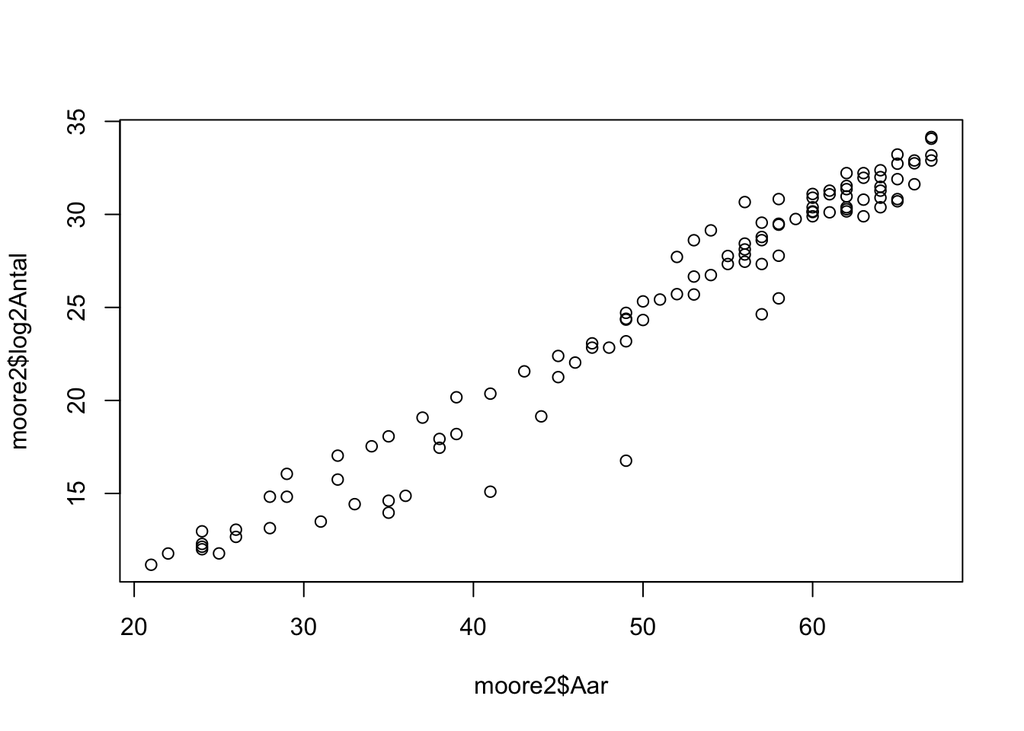

```r
moore2 <- moore %>%
  rename(Antal = Transistorer) %>%
  mutate(log2Antal = log2(Antal))

plot(moore2$Aar, moore2$log2Antal)
```

Jeps.

### (b) Opskriv den lineære regressionsmodel for data. Estimer parametrene i modellen, og lav figurer til modelkontrol. I residualplottet skal du indtegne to vandrette linjer, der skærer andenaksen i punkterne ±2sr

, hvor sr er skønnet over spredningen i regressionsmodellen.

$$log2Antal_i\sim N(\alpha+\beta Aar_i,\sigma^2 )$$

```r
alpha_hat <- summary(lm(log2Antal~ Aar , data = moore2))$coefficients[1]
beta_hat <- summary(lm(log2Antal~ Aar , data = moore2))$coefficients[2]
sigma <- summary(lm(log2Antal~ Aar , data = moore2))$sigma

alpha_hat
```

```
## [1] -0.6829498
```

```r
beta_hat
```

```
## [1] 0.5067275
```

```r
sigma
```

```
## [1] 1.457787
```

har estimerede parameterne.

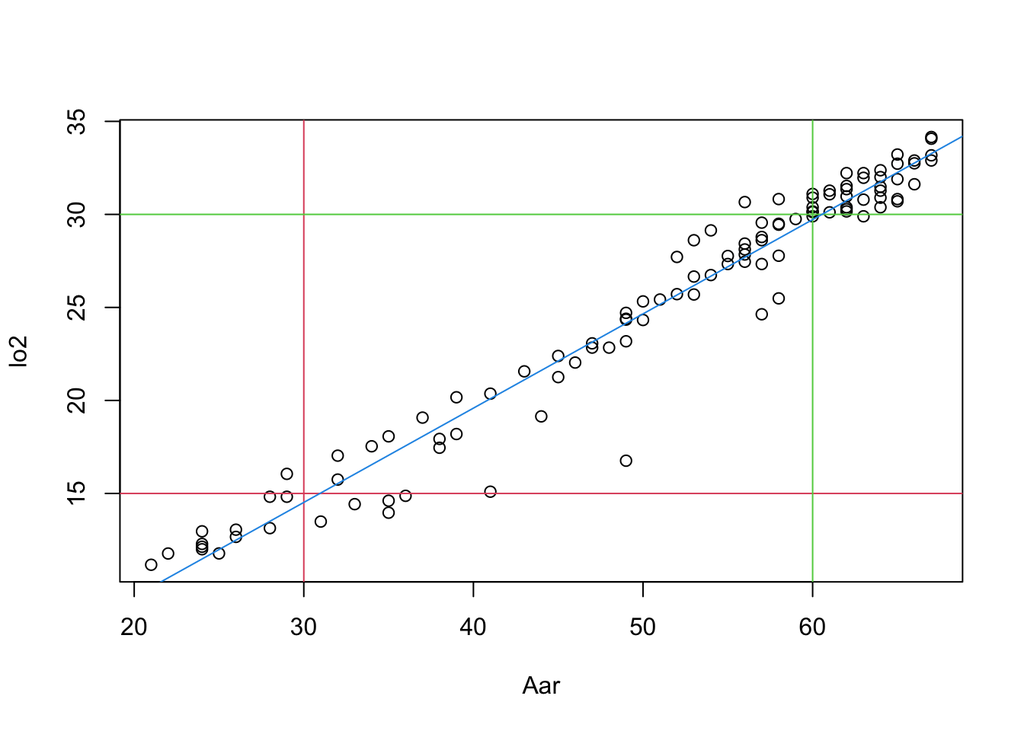

```r
plot(moore2$Aar, moore2$log2Antal, xlab = "Aar", ylab = "lo2")
abline(v = 30, col = 2)
abline(h = 15, col = 2)
abline(v = 60, col = 3)
abline(h = 30, col = 3)
abline(alpha_hat, beta_hat, col = 4)
```

Blå er den estimerede linje.

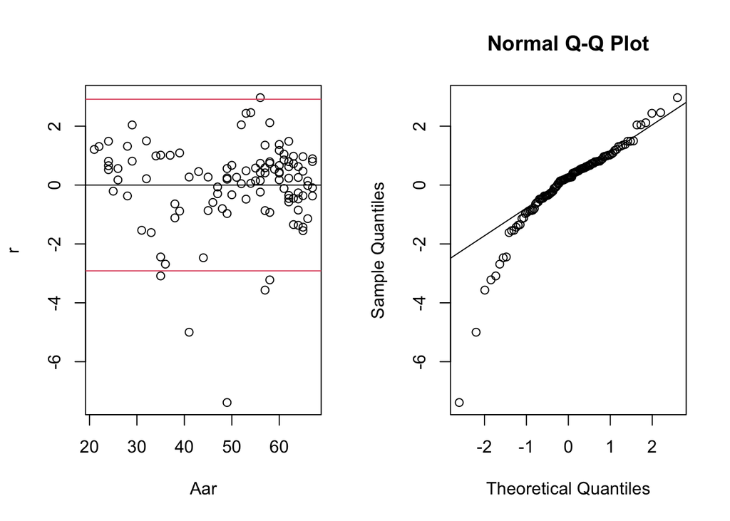

```r
r = moore2$log2Antal - (alpha_hat + beta_hat * moore2$Aar)
par(mfrow = c(1,2))
plot(moore2$Aar, r, xlab = "Aar")
abline(h = 2 * sigma, col = 2)
abline(h = -(2 * sigma), col = 2)
abline(0,0)
qqnorm(r)
qqline(r)
```

modelt kontrol er residual plot og qqplot. Kipur kode fra slides.

Til venstre ser vi om der er noget systematisk ændring i varians. Ser på hvordan den klumper sammen. De røde er +- skøn over spredning.

QQ viser at den ikke er normal fordelt. Men i midten er den ok bare ikke i enderne.

### c) Beregn 95%-konfidensintervaller for henholdsvis skæring og hældning i den lineære sammenhæng mellem middelværdien af log2Antal og Aar. Eftervis, at konfidensintervallet for

hældningen, fundet gennem et kald til confint, er korrekt ved at bruge oplysninger i output fra summary.

konfidens udregning laver vi med hældning gange kvantilen.

```r
confint(lm(moore2$log2Antal ~ moore2$Aar))
```

```
##                  2.5 %    97.5 %
## (Intercept) -1.7747438 0.4088442
## moore2$Aar   0.4858668 0.5275881
```

Vi har 108 observation og 106 frihedsgrader og estimer skæring og hældning

```r
attach(moore2)
model = lm(log2Antal ~ Aar)
hældning <- summary(model)$coefficients[2]
sdafvig <- summary(model)$coefficients[4]
hældning + c(-1,1) * qt(0.975, 106) * sdafvig
```

```
## [1] 0.4858668 0.5275881
```

### d) Overvej, om data er i overensstemmelse med en teori, der siger, at antallet af transitorer på

en chip fordobles hvert andet år ?

vi kan se at det ligger ret centralt indenfor vores konfidensinterval, hvorfor data ikke struder imdo denne hypotese.

## webbog opgave 3.2

I denne opgave skal I se på muligheden for at prædiktere den tid, der skal bruges til at teste et program ud fra oplysning om, hvor lang tid der er brugt på at kode programmet. Data i filen Testtid.csv indeholder oplysninger for 95 programmer. Filen har to søjler, hvor første søjle er tid 3.9. Opgaver til kapitel 3 95 brugt på at kode, og anden søjle er tid brugt på at teste programmet (begge tider er i timer). Data er simulerede ud fra oplysningerne i figur 3 i artiklen Software effort estimation with multiple linear regression: review and practical application. I opgaven her skal I etablere en lineær sammenhæng mellem middelværdien af logaritmen til testtiden og logaritmen til kodningstiden og bruge denne sammenhæng til at prædiktere testtiden ved forskellige givne værdier af kodningstiden.

### (a)

Lad logKode være en vektor med logaritmen til kodningstiderne, og lad logTest være en vektor med logaritmen til testtiderne. Lav en figur, hvor logTest afsættes mod logKode. Er det rimeligt at sige, at der er en lineær sammenhæng mellem de to variable ? Opskriv den lineære regressionsmodel for data, og estimer parametrene i denne via lm og summary. Indtegn den fundne linje i figuren med data. Prøv i ord at beskrive sammenhængen i data, ud fra hvad du ser i figuren.

```r
testtid <- read.csv("../MatStat-R/data/JLJfiler/Testtid.csv")
```

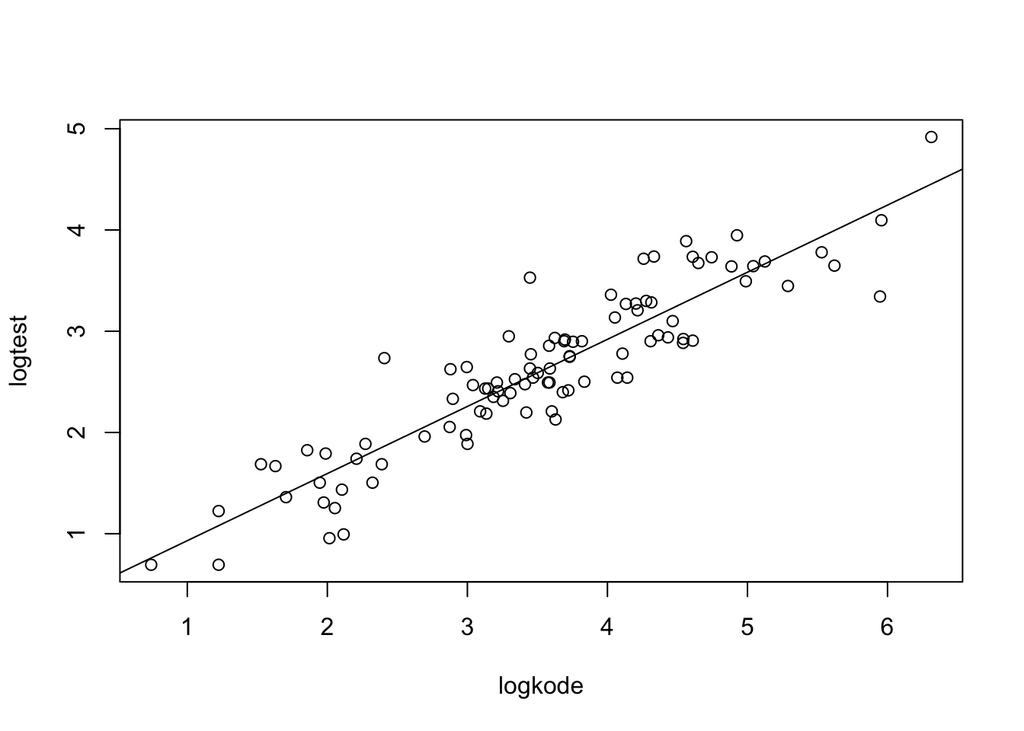

```r
logkode <- log(testtid$KodningsTid)
logtest <- log(testtid$TestTid)
lmUD <- lm(logtest ~ logkode)
plot(logkode, logtest)
abline(lmUD)
```

### (b)

Lav et test, for hypotesen at hældningen er nul. Hvad bliver konklusionen af dit test ? Lav dernæst et 95%-konfidensinterval for hældningen. Kommenter på betydningen af, at hældningen ser ud til at være væsentlig mindre end 1. Lav et skøn over ændringen i middelværdi af logTest mellem en værdi af logKode på 2 og 4, og sammenhold denne med spredningen omkring regressionslinjen (jævnfør din egen beskrivelse af sammenhængen i data sidst i foregående spørgsmål).

```r
confint(lmUD)
```

```
##                  2.5 %    97.5 %
## (Intercept) 0.04298293 0.4929072
## logkode     0.60269980 0.7237131
```

konfident interval er en god.

Test skal vi køre

```r
summary(lmUD)
```

```
##
## Call:
## lm(formula = logtest ~ logkode)
##
## Residuals:
##      Min       1Q   Median       3Q      Max
## -0.86882 -0.22601 -0.00309  0.19683  0.97541
##
## Coefficients:
##             Estimate Std. Error t value Pr(>|t|)
## (Intercept)  0.26795    0.11329   2.365   0.0201 *
## logkode      0.66321    0.03047  21.766   <2e-16 ***
## ---
## Signif. codes:  0 '***' 0.001 '**' 0.01 '*' 0.05 '.' 0.1 ' ' 1
##
## Residual standard error: 0.331 on 93 degrees of freedom
## Multiple R-squared:  0.8359, Adjusted R-squared:  0.8341
## F-statistic: 473.8 on 1 and 93 DF,  p-value: < 2.2e-16
```

se p værdi om den kan være lig med nul.

```r
ny_data <- data.frame(logkode = log(c(2,4)))
predict(lmUD, ny_data, interval = "confidence")
```

```
##         fit       lwr      upr
## 1 0.7276447 0.5422665 0.913023
## 2 1.1873444 1.0402385 1.334450
```

### (c) Lav et 95%-konfidensinterval for middelværdien af logTest, når logKode er 6.

Lav dernæst et prædiktionsinterval for en kommende måling, når logKode er 6. Prøv at forklare, hvorfor prædiktionsintervallet er noget bredere end konfidensintervallet.

```r
ny_data <- data.frame(logkode = log(c(6)))
predict(lmUD, ny_data, interval = "confidence")
```

```
##        fit      lwr      upr
## 1 1.456251 1.330445 1.582058
```

```r
ny_data <- data.frame(logkode = log(c(6)))
predict(lmUD, ny_data, interval = "prediction")
```

```
##        fit       lwr      upr
## 1 1.456251 0.7869523 2.125551
```

konfidens er de steder en potentiel middelværdi kan være. ens predicion er de mulige værdier den kan tage.

> konfidentinterval omtaler i dette tilfælde mean af potentialle observation inden for prediction intervallet, som er de funktiosnværdier det punkt man prøver at predicte med 05% sikkerhed.

> i preiction bruger man en større standard afvigelse. se 3.5

### (d) I dette spørgsmål skal du beregne konfidensintervallet og prædiktionsintervallet i mange

punkter og indtegne disse som en kurve i figuren fra spørgsmål (a). Du kan finde inspiration til konstruktion af figuren i afsnit 3.5 i det skjulte punkt “Test dig selv”. Til beregningen kan du kalde predict med nye datapunkter givet ved data.frame(logKode=c(0:100)*0.07).

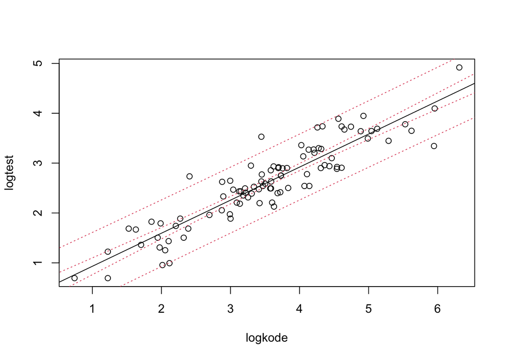

```r
plot(logkode, logtest)
abline(lmUD)

pktlogColi= c(0:100) * 0.07

nyData <- data.frame(logkode=pktlogColi)

pred_conf_UD <- predict(lmUD, nyData, interval = "confidence")
pred_pred_UD <- predict(lmUD, nyData, interval = "predict")

lines(pktlogColi, pred_conf_UD[, 2], lty = 3, col = 2)
lines(pktlogColi, pred_conf_UD[, 3], lty = 3, col = 2)

lines(pktlogColi, pred_pred_UD[, 2], lty = 3, col = 2)
lines(pktlogColi, pred_pred_UD[, 3], lty = 3, col = 2)
```

Det store er prediction mens det mindre er konfidens intervallet.

## webbog opgave 3.4 (Desværre hedder datafilen “LambertBeer.txt” og ikke “LambertBeer.csv”. Indlæs med kommandoen ## read.table(“../Data/LambertBeer.txt”))

Denne opgave omhandler måden, hvorpå absorption af lys i en væske afhænger af koncentrationen af et absorberende molekyle i væsken, og hvordan vi kan bruge dette til at estimere koncentrationen ud fra en målt lysintensitet. Man måler lysintensiteten I ved forskellige kendte koncentrationer af det absorberende molekyle. På denne måde får man etableret en kalibreringkurve, der 3.9. Opgaver til kapitel 3 97 efterfølgende kan benyttes til at finde koncentrationen af molekylet i en prøve ud fra en måling af lysintensiteten efter lysets passage gennem prøven. Absorption af denne type beskrives typisk via Lambert-Beers lov:

$$I=I_0 exp{-\epsilon vc}$$

Her er ε absorptionskoefficienten for det absorberende molekyle, v er vejlængden gennem materialet, c er koncentrationen af molekylet og I0 er lysintensiteten når koncentrationen er nul. I denne opgave betragter vi en serie målinger af lysintensiteten I som funktion af koncentrationen for en opløsning af Rhodamine 6G i ethanol. Den benyttede vejlængde gennem opløsningen er v = 1.00cm. Egentligt burde man i modelleringen af data også tage hensyn til, at koncentrationen af opløsningsmidlet ethanol ændrer sig, når koncentrationen af Rhodamine ændres, men denne effekt er så lille, at vi kan se bort fra den. Tager vi logartimen på begge sider i Lambert-Beers lov (3.2), får vi

$$H=\alpha - \epsilon vc$$

hvor α = log(I0) og H = log(I). Data i filen LambertBeer.csv giver den målte værdi af lysintensiteten I for 16 forskellige valg af koncentrationen. Filen har to søjler, hvor første søjle er koncentration, og anden søjle er lysintensiteten

```r
lambertbeer <- read.table("../MatStat-R/data/JLJfiler/LambertBeer.txt")
```

### 1. Dan en variabel logLys med logaritmen til de målte lysintensiteter og en variabel konc med

koncentrationerne af Rhodamine 6G. Lav en figur, hvor logLys afsættes mod koncentrationen konc. Synes I, at der er en lineær sammenhæng i data ? Synes I, at sammenhængen er god, med henblik på at estimere koncentration ud fra lysintensiteten ?

```r
logLys <- log(lambertbeer[, 2])
konc <- lambertbeer[,1]
```

afsæt loglys mod konc, ser om der er en lineæ sammenhæng

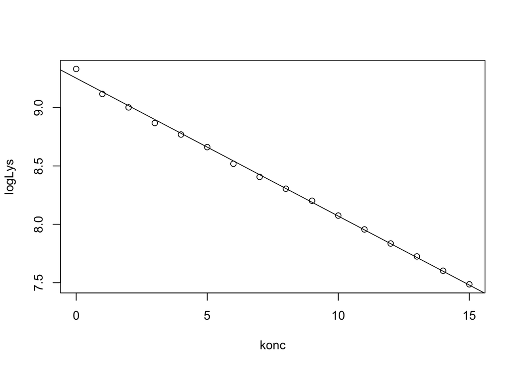

```r
plot(konc, logLys)
abline(lm(logLys ~ konc))
```

danner variablen loglys med logaritmen.

afsætter loglys mod konc og se om der er en sammenhæng. Den er lineær.

Det er en god måde at estimer koncentrationen.

### 2. Opskriv den lineære regressionsmodel, hvor respons er logaritmen til lysintensiteten, og

den forklarende variabel er koncentration. Forklar, at regressionskoefficienten β i denne model er β = −εv. Estimer modellen og indtegn den estimerede linje i figuren ovenfor.

```r
summary(lm(logLys ~ konc))
```

```
##
## Call:
## lm(formula = logLys ~ konc)
##
## Residuals:
##       Min        1Q    Median        3Q       Max
## -0.030553 -0.015363  0.000549  0.004707  0.078325
##
## Coefficients:
##              Estimate Std. Error t value Pr(>|t|)
## (Intercept)  9.252018   0.012112  763.86   <2e-16 ***
## konc        -0.118153   0.001376  -85.88   <2e-16 ***
## ---
## Signif. codes:  0 '***' 0.001 '**' 0.01 '*' 0.05 '.' 0.1 ' ' 1
##
## Residual standard error: 0.02537 on 14 degrees of freedom
## Multiple R-squared:  0.9981, Adjusted R-squared:  0.998
## F-statistic:  7375 on 1 and 14 DF,  p-value: < 2.2e-16
```

$$logLys \sim 9.25 - 0.118 * konc$$

```r
source("../MatStat-R/source/Rfunktioner.R")
inversReg(lm(logLys ~ konc), log(2654))
```

```
## $estimat
## [1] 11.57982
##
## $konfidensinterval
## [1] 11.09670 12.06803
```

```r
inversReg(lm(logLys ~ konc), log(4512))
```

```
## $estimat
## [1] 7.088432
##
## $konfidensinterval
## [1] 6.613225 7.563126
```

```r
inversReg(lm(logLys ~ konc), log(7688))
```

```
## $estimat
## [1] 2.578023
##
## $konfidensinterval
## [1] 2.084439 3.065463
```

Lys = 2654, Lys = 4512 og Lys = 7688. Lav en tabel med resultaterne.

## webbog opgave 3.6

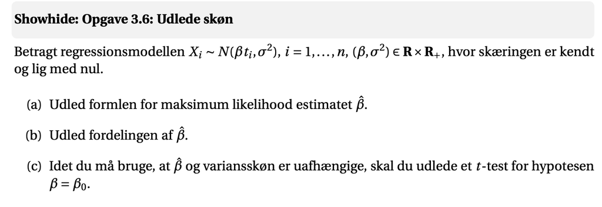

## webbog opgave 2.3

```r
goegen <- read.csv("../MatStat-R/data/JLJfiler/Goegen.csv")

goegen %>% head()
```

```
##       Art   Form
## 1 Engpibe 0.7419
## 2 Engpibe 0.7522
## 3 Engpibe 0.7751
## 4 Engpibe 0.7500
## 5 Engpibe 0.7613
## 6 Engpibe 0.7511
```

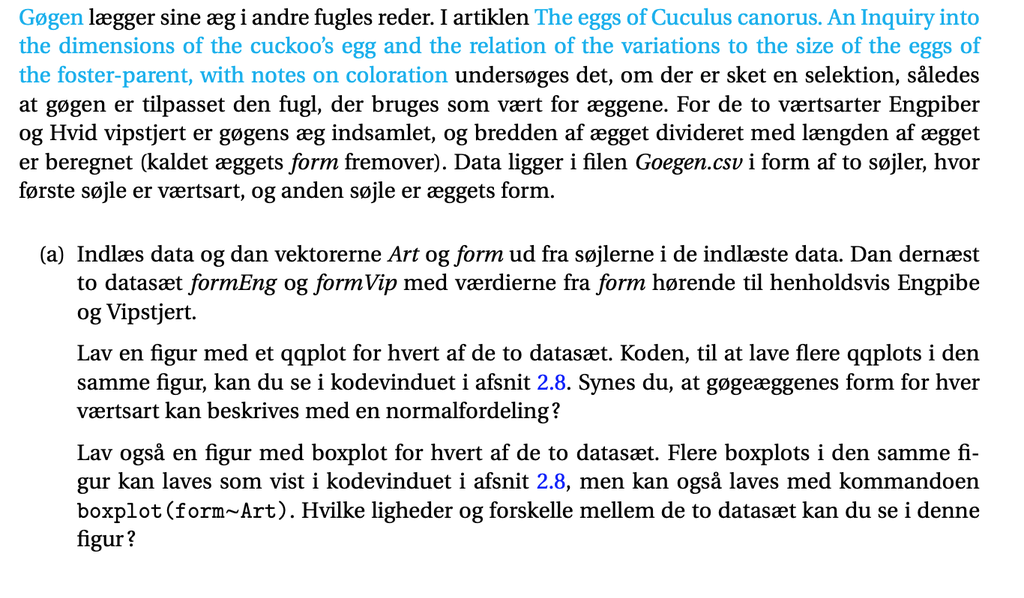

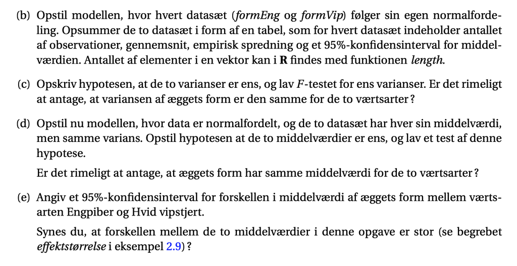

### a)

dan Art og form

```r
attach(goegen)

art <- factor(Art)
form <- Form
```

Dan formEng og formVip

```r
formEng <- goegen$Form[goegen$Art == "Engpibe"]
formVip <- goegen$Form[goegen$Art == "Vipstjert"]
```

Lav en figur med qqplot:

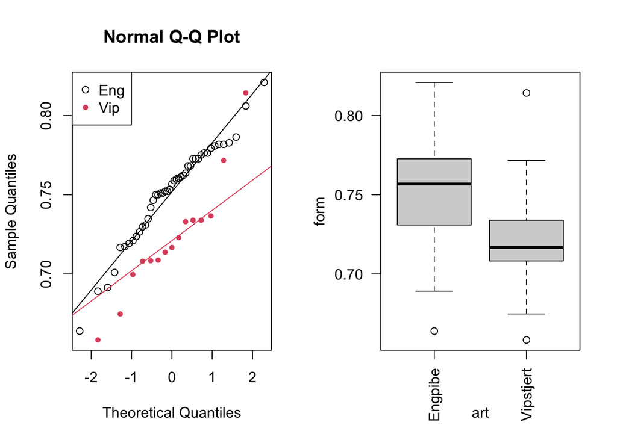

```r
par(mfrow = c(1,2))
qqnorm(formEng, ylim = range(formEng, formVip))
qqline(formEng)
points(qqnorm(formVip, plo = FALSE), col = 2, pch = 20)
qqline(formVip, col = 2)
legend("topleft", legend = c("Eng", "Vip"), col = c(1,2), pch = c(1,20))

boxplot(form ~ art, las = 2)
```

den for eng ser merre normal fordelt ud end vip. Den røde ser ud i ender er der en del afvigelser.

I boxplot når vi samme konklusion.

### b)

$$form_{i_g} \sim N(\alpha_g,\sigma_g^2), g={Eng,Vip}$$

```r
confint(lm(form~ art - 1))
```

```
##                  2.5 %    97.5 %
## artEngpibe   0.7422497 0.7616969
## artVipstjert 0.7054449 0.7391284
```

-1 gør vi at fælles hældning.

vi ser på forskel i hældning, fordi de to grupper intercept kommer til at være hældning.

```r
table <- matrix(c(length(formEng), round(mean(formEng), 2), round(sd(formEng), 2),
                  0.7422, 0.7617,
                  length(formVip), round(mean(formVip), 2),
                  round(sd(formVip), 2), 0.7422 - 0.0491, 0.7617 - 0.010),
                nrow = 2, byrow = TRUE)
rownames(table) <- c("Eng", "Vip")
colnames(table) <- c("Observatoin", "Gennemsnit", "Spredning", "Nedre", "Øvre")
table
```

[output not shown]

### c)

```r
var.test(formEng, formVip)
```

```
##
##  F test to compare two variances
##
## data:  formEng and formVip
## F = 0.7099, num df = 44, denom df = 14, p-value = 0.3793
## alternative hypothesis: true ratio of variances is not equal to 1
## 95 percent confidence interval:
##  0.2670751 1.5474234
## sample estimates:
## ratio of variances
##          0.7098961
```

0.38 godkedn H0, høj p værdi betyder vi ikke forkaster H0.

### d)

kan middelværid være ens.

```r
t.test(formEng, formVip, var.equal = TRUE)
```

```
##
##  Two Sample t-test
##
## data:  formEng and formVip
## t = 3.0557, df = 58, p-value = 0.003391
## alternative hypothesis: true difference in means is not equal to 0
## 95 percent confidence interval:
##  0.01023949 0.04913384
## sample estimates:
## mean of x mean of y
## 0.7519733 0.7222867
```

vi forkaster H0.

De to middelværdier er ikke ens.

```r
confint(lm(form ~ art))
```

```
##                    2.5 %      97.5 %
## (Intercept)   0.74224974  0.76169692
## artVipstjert -0.04913384 -0.01023949
```

forskel ligger mellem konfident

## webbog opgave 3.7

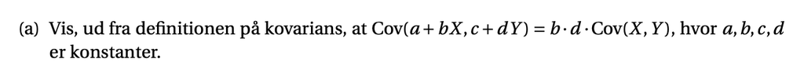